# 2 Scientific visualization

The visualization ecosystem in Julia is evolving very quickly. Among the various visualization projects, Makie.jl by Danisch and Krumbiegel (2021) is the most advanced for [scientific visualization](https://en.wikipedia.org/wiki/Scientific_visualization).

Makie.jl is currently organized in backend modules:

- **GLMakie.jl** is the preferred backend for interactive *high-performance* visualization.
- **WGLMakie.jl** is the preferred backend for interactive visualization on the *web browser*.
- **CairoMakie.jl** is the preferred backend for *publication-quality* static visualization.

In this book, we use **CairoMakie.jl**:

```julia
import CairoMakie as Mke
```

**Note**

We import the backend as `Mke` to avoid polluting the Julia session with names from the visualization stack.

Makie.jl provides a plot recipe system developed after Plots.jl by Breloff (2023), which enables automatic visualization of custom Julia types. The GeoStats.jl framework is integrated with this system, and provides powerful visualization functions for geospatial data.

Julia will automatically trigger the compilation of these visualization functions whenever GeoStats.jl and Makie.jl are loaded in the same session:

```julia
using GeoStats
```

## 2.1 The viz/viz! function

The main visualization function that the framework provides is the `viz`/`viz!` function. The `viz` function *creates a scene* and displays geometries within a geospatial domain. On the other hand, the `viz!` function adds more geometries to an *existing scene*.

Let’s create a small geotable over a Cartesian grid for illustration purposes:

```julia
img = georef((A=rand(10, 10), B=rand(10, 10)))
```

90 rows omitted

| 100×3 GeoTable over 10×10 CartesianGrid A Continuous [NoUnits] | 100×3 GeoTable over 10×10 CartesianGrid B Continuous [NoUnits] | 100×3 GeoTable over 10×10 CartesianGrid geometry Quadrangle 🖈 Cartesian{NoDatum} |
| --- | --- | --- |
| 0.0913883 | 0.402711 | Quadrangle((x: 0.0 m, y: 0.0 m), ..., (x: 0.0 m, y: 1.0 m)) |
| 0.520809 | 0.739855 | Quadrangle((x: 1.0 m, y: 0.0 m), ..., (x: 1.0 m, y: 1.0 m)) |
| 0.744819 | 0.459372 | Quadrangle((x: 2.0 m, y: 0.0 m), ..., (x: 2.0 m, y: 1.0 m)) |
| 0.550016 | 0.773958 | Quadrangle((x: 3.0 m, y: 0.0 m), ..., (x: 3.0 m, y: 1.0 m)) |
| 0.900614 | 0.726076 | Quadrangle((x: 4.0 m, y: 0.0 m), ..., (x: 4.0 m, y: 1.0 m)) |
| 0.615054 | 0.319192 | Quadrangle((x: 5.0 m, y: 0.0 m), ..., (x: 5.0 m, y: 1.0 m)) |
| 0.801225 | 0.869329 | Quadrangle((x: 6.0 m, y: 0.0 m), ..., (x: 6.0 m, y: 1.0 m)) |
| 0.468419 | 0.801778 | Quadrangle((x: 7.0 m, y: 0.0 m), ..., (x: 7.0 m, y: 1.0 m)) |
| 0.382545 | 0.577947 | Quadrangle((x: 8.0 m, y: 0.0 m), ..., (x: 8.0 m, y: 1.0 m)) |
| 0.734747 | 0.226469 | Quadrangle((x: 9.0 m, y: 0.0 m), ..., (x: 9.0 m, y: 1.0 m)) |
| ⋮ | ⋮ | ⋮ |

**Note**

The `georef` function creates a `CartesianGrid` starting at the origin whenever the domain is omitted. The size of the grid is taken as the size of the first array in the named tuple:

```julia
img.geometry
```

```
10×10 CartesianGrid
├─ minimum: Point(x: 0.0 m, y: 0.0 m)
├─ maximum: Point(x: 10.0 m, y: 10.0 m)
└─ spacing: (1.0 m, 1.0 m)
```

**NoteTip for all users**

To create a named tuple with a single key in Julia, we need an extra comma after the key/value pair:

```julia
(A=rand(10, 10),)
```

```
(A = [0.019433934925863983 0.5885968911172444 … 0.5892743577293871 0.41793527993278146; 0.06165011779680629 0.12131586003453154 … 0.42828588474223583 0.6577721799139218; … ; 0.0072698867835037095 0.5418346583442929 … 0.780367467703769 0.48441530742139516; 0.2610101205114794 0.3088162050470913 … 0.35…
```

or a semicolon before the key/value pair:

```julia
(; A=rand(10, 10))
```

```
(A = [0.9687928435048537 0.9072319139272962 … 0.42747914712334123 0.705336983466693; 0.5061181661397015 0.07716336119936651 … 0.265646263741775 0.7001026416077074; … ; 0.28628637771268695 0.6460416172611732 … 0.019187912304477805 0.748493034482716; 0.0325001728786134 0.6938398800647125 … 0.483728079…
```

By default, all geometries are displayed with a single color:

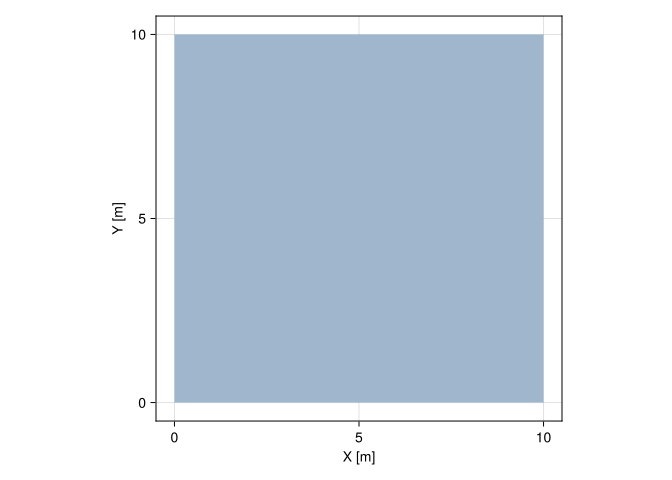

```julia
viz(img.geometry)
```

We can pass any vector of Colors.jl or numbers (automatically converted to colors) to the function via the `color` option. It is common to pass colors from another column of the geotable:

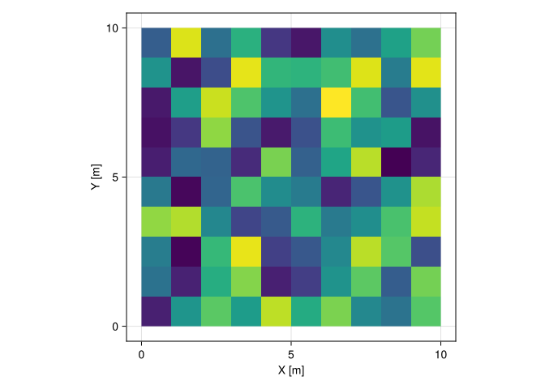

```julia
viz(img.geometry, color = img.A)
```

but any vector with the same length can be passed:

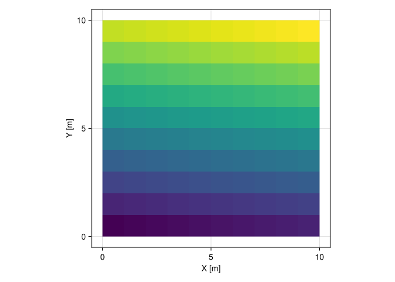

```julia
viz(img.geometry, color = 1:length(img.A))
```

The `alpha` option can be used to control the transparency of each geometry in the domain:

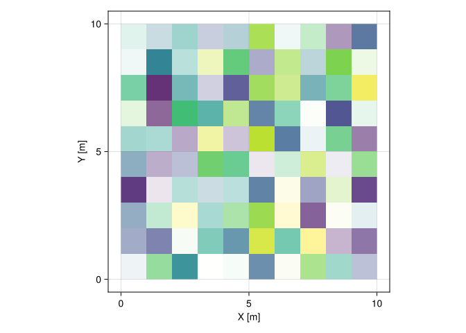

```julia
viz(img.geometry, color = img.B, alpha = rand(length(img.B)))
```

Other aesthetic options are available in the official documentation.

As another example, consider the visualization of data over a set of geometries:

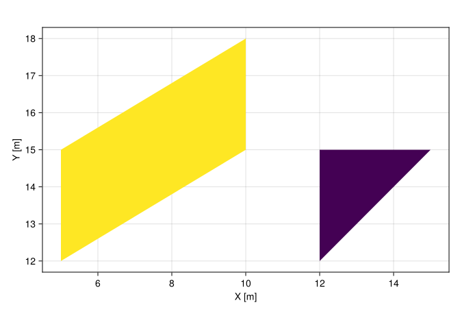

```julia
geoms = [
  Triangle((12, 12), (15, 15), (12, 15)),
  Quadrangle((5, 12), (10, 15), (10, 18), (5, 15))
]

gis = georef((A=[0.1, 0.2], B=[0.3, 0.4]), geoms)

viz(gis.geometry, color = gis.A)
```

We can create a scene with the geometries from the first geotable (“raster data”), and then add the geometries from the second geotable (“vector data”):

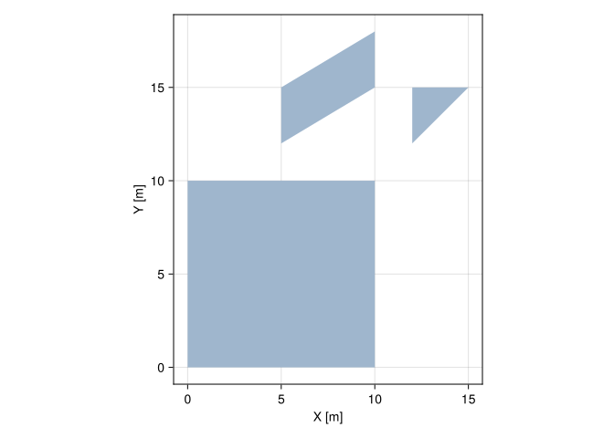

```julia
viz(img.geometry)
viz!(gis.geometry)

# display current figure
Mke.current_figure()
```

Let’s add an additional set of points and line segments to conclude the example:

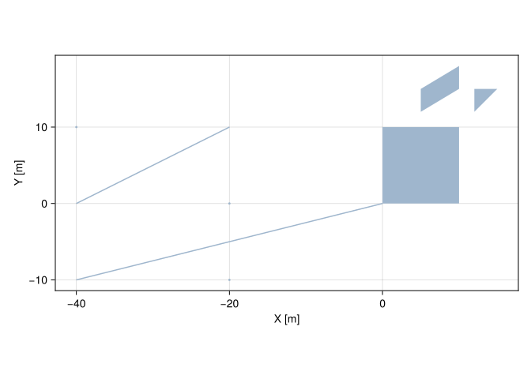

```julia
viz!([Point(-20, -10), Point(-20, 0), Point(-40, 10)])
viz!([Segment((-40, -10), (0, 0)), Segment((-40, 0), (-20, 10))])

Mke.current_figure()
```

**NoteTip for advanced users**

Makie.jl dispatches the `viz` and `viz!` functions whenever it encounters a geospatial domain, a vector of geometries or a single geometry from Meshes.jl. This means that you can replace `viz` with `Mke.plot` and `viz!` with `Mke.plot!` in scripts and the result will be the same.

**NoteTip for advanced users**

In the case of `Mesh` domains, it is also possible to specify a color for each vertex of the mesh. In this case, the `viz` and `viz!` functions fill in the domain with using the interpolation routine from the graphics library:

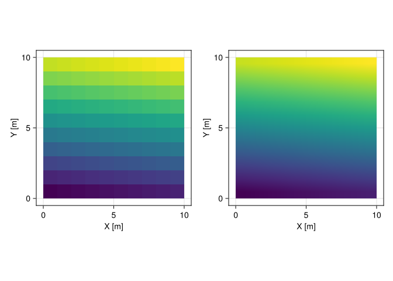

```julia
grid = CartesianGrid(10, 10)

fig = Mke.Figure()
viz(fig[1,1], grid, color = 1:nelements(grid))
viz(fig[1,2], grid, color = 1:nvertices(grid))
fig
```

### 2.1.1 Reference systems

The `viz` and `viz!` functions are aware of coordinate reference systems, which is a quite unique feature of the framework, explored in the chapter Map projections.

Below is a preview of this feature in action:

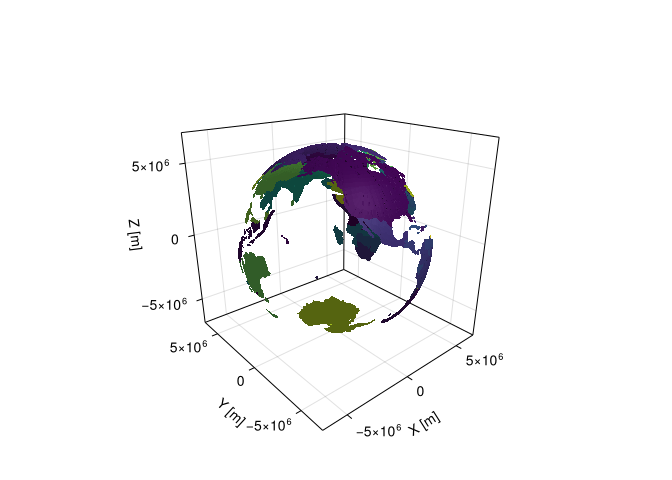

```julia
using GeoIO

world = GeoIO.load("data/countries.geojson")

viz(world.geometry, color = 1:nrow(world))
```

### 2.1.2 Axis customization

To customize the figure and axis, please refer to Makie.jl documentation. The following example illustrates the construction of a figure with two subfigures side by side. Each subfigure has an axis with title and axis labels:

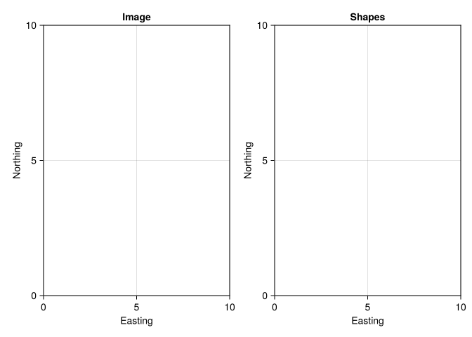

```julia
fig = Mke.Figure()
ax1 = Mke.Axis(fig[1, 1], title = "Image", xlabel = "Easting", ylabel = "Northing")
ax2 = Mke.Axis(fig[1, 2], title = "Shapes", xlabel = "Easting", ylabel = "Northing")
fig
```

We can use `viz!` to add geospatial data to the existing axes:

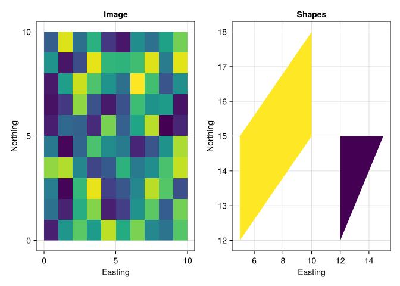

```julia
viz!(ax1, img.geometry, color = img.A)
viz!(ax2, gis.geometry, color = gis.B)
fig
```

Or use `viz` to create a new axis in a new subfigure:

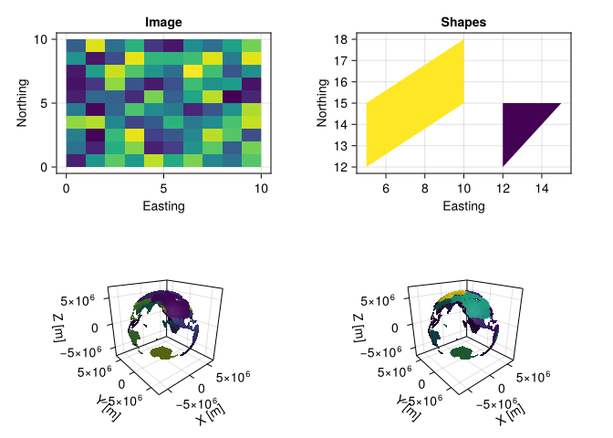

```julia
viz(fig[2, 1], world.geometry, color = 1:nrow(world))
viz(fig[2, 2], world.geometry, color = area.(world.geometry))
fig
```

## 2.2 The cbar function

Any vector of Julia objects implementing the `Colorfy.repr` function from the Colorfy.jl module can be passed to the `color` option of `viz`/`viz!`. The final vector of colors is a function of the `colormap` from ColorSchemes.jl and `colorrange` options. To reproduce this behavior in the colorbar, the framework provides the `cbar` function:

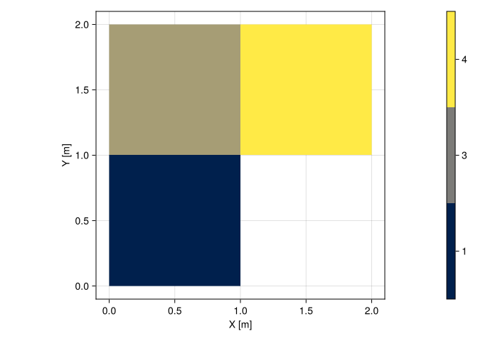

```julia
grid = CartesianGrid(2, 2)
vals = [1, missing, 3, 4]
cmap = "cividis"

fig = Mke.Figure()
viz(fig[1,1], grid, color = vals, colormap = cmap)
cbar(fig[1,2], vals, colormap = cmap)
fig
```

The function is similar to Makie’s colorbar function, but addresses various practical challenges with `missing` values, units, etc. The `colorrange` option is useful to set the range of colors in the presence of multiple geotables:

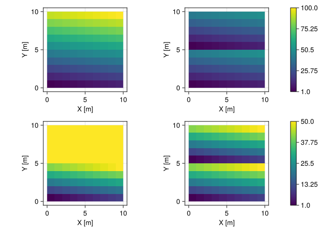

```julia
grid = CartesianGrid(10, 10)
val1 = 1.0:100.0
val2 = [1.0:50.0; 1.0:50.0]

fig = Mke.Figure()

viz(fig[1,1], grid, color = val1, colorrange = (1.0, 100.0))
viz(fig[1,2], grid, color = val2, colorrange = (1.0, 100.0))
cbar(fig[1,3], val1, colorrange = (1.0, 100.0))

viz(fig[2,1], grid, color = val1, colorrange = (1.0, 50.0))
viz(fig[2,2], grid, color = val2, colorrange = (1.0, 50.0))
cbar(fig[2,3], val2, colorrange = (1.0, 50.0))

fig
```

## 2.3 Basic viewer

As geospatial data scientists we are often interested in quick inspection of intermediate results from multivariate geostatistical analysis. Visualizing all the variables manually with `viz`/`viz!` can be very time consuming. To address this issue, the framework provides a basic `viewer` that displays all variables stored in a geotable:

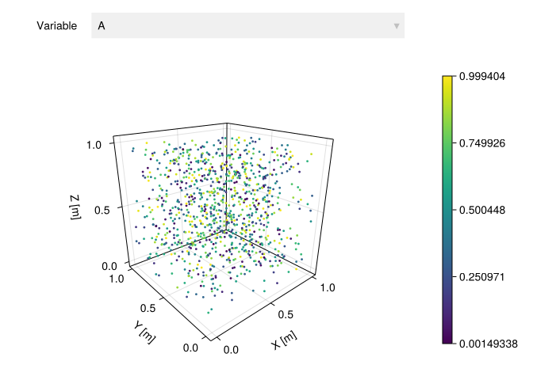

```julia
geotable = georef((A=rand(1000), B=rand(1000)), rand(Point, 1000))

viewer(geotable)
```

**Note**

The `rand(Point, 1000)` function call creates `1000` random `Point`s in 3D space.

It adds interactive elements to the scene, including a menu to select the variable used as color, and a color bar that automatically updates upon menu selection. The `viewer` will be particularly useful when we start to work with geospatial transforms in **Part II** of the book. The pipe operator (`|>`) in Julia will be preferred for reasons that will become clear later:

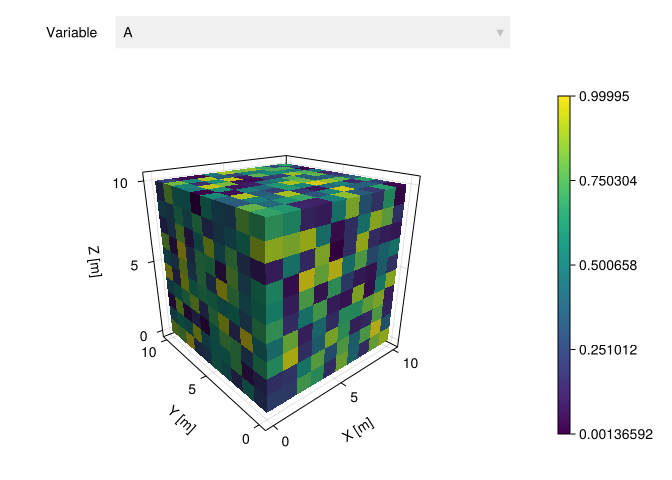

```julia
geotable = georef((A=rand(1000), B=rand(1000)), CartesianGrid(10, 10, 10))

geotable |> viewer
```

**Note**

The `viewer` automatically selects a `cbar` for variables based on data science traits from the DataScienceTraits.jl module. It also recognizes and displays units from the Unitful.jl module:

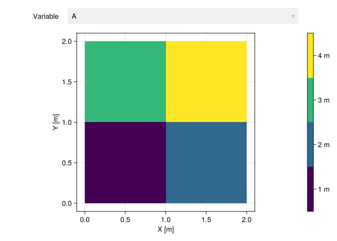

```julia
geotable = georef((; A=[1,2,3,4]u"m"), CartesianGrid(2, 2))

geotable |> viewer
```

We are now equipped with a set of visualization functions that can really improve the speed at which we explore and analyze geospatial data. These functions provide a consistent set of aesthetic options that we will cover in more detail with future examples.

Before we start learning the advanced features of the framework, we would like to say a few words about integration with existing GIS technology.

Breloff, Tom. 2023. *Plots.jl*. V. v1.38.17. Zenodo, released July. https://doi.org/10.5281/zenodo.8183938.

Danisch, Simon, and Julius Krumbiegel. 2021. “Makie.jl: Flexible High-Performance Data Visualization for Julia.” *Journal of Open Source Software* 6 (65): 3349. https://doi.org/10.21105/joss.03349.